# Stat 380 Final Project

Abeer Mathur, Marvin Jakobs, Divyesh Johri, Cinah Pourhamidi

2022-12-01

```r
library(dplyr)
library(tidyverse)
library(readr)
library(rpart)
library(randomForest)
library(stats)
library(FNN)
library(fastDummies)
library(kernlab)
```

#### Load and clean datasets

```r
CODGameModes <- read.csv("https://raw.githubusercontent.com/Abeermathur7/STAT380Final/main/CODGameModes.csv")
CODGames_p1_380 <- read.csv("https://raw.githubusercontent.com/Abeermathur7/STAT380Final/main/CODGames_p1_380.csv")
CODGames_p2_380 <- read.csv("https://raw.githubusercontent.com/Abeermathur7/STAT380Final/main/CODGames_p2_380.csv")

CODGames<- rbind(CODGames_p1_380,CODGames_p2_380) #combine raw data

dupModes <- CODGameModes
dupModes$Mode <- paste("HC -", dupModes$Mode) #adding HC mode limits
allModes <- rbind(dupModes,CODGameModes)
```

In this project we are looking at the CODGames_p1_380,CODGames_p2_380 and CODGameModes files. CODGameMode includes the list of game modes that can be played, and the other datasets incude details on specific games played and details about those matches. We first begin by combining the two part 1 and part2 datasets into one unified dataset called CODGames using rbind. We also created dubModes which provided us with the game modes, but since they did not contain “HC-” so we had to do some cleaning and use rbind again so we can have all the game modes, score limits and time limits within one table.

### Task 1 (Exploratory Analysis):

#### Research Question: Which game mode is most likely to reach the score limit?

```r
scoreLimit <- left_join(CODGames,allModes, by = c("GameType"="Mode")) #add score limit column

scoreLimit <- tidyr::separate(data = scoreLimit, col = Result, sep = "-", into = c("score1","score2")) #put each team score into individual columns

scoreLimit <- mutate(scoreLimit, limitReached = ifelse(score1 == ScoreLimit | score2 == ScoreLimit,1,0)) #note if either team reached the limit

limitList <- scoreLimit %>% group_by(GameType) %>% tally(limitReached) #group by and count games that reached score limit for each mode
totalCount <- scoreLimit %>% group_by(GameType) %>% summarise(count = n()) #total games of each mode played
limitList$total <- totalCount$count
limitList <- mutate(limitList, limitProb = n/total) #find ratio of score limit reached to games played
limitList %>% arrange(desc(limitProb)) #print descending
```

```
## # A tibble: 8 × 4
##   GameType                n total limitProb
##   <chr>               <dbl> <int>     <dbl>
## 1 Domination              3     3     1
## 2 HC - Domination        11    11     1
## 3 HC - Hardpoint         96   100     0.96
## 4 Hardpoint             155   167     0.928
## 5 Kill Confirmed          6     7     0.857
## 6 HC - TDM              288   350     0.823
## 7 TDM                   141   187     0.754
## 8 HC - Kill Confirmed    10    14     0.714
```

In the dataset there are a variety of “Game Types” and they can vary from Team Death Match, Domination to Hardpoint. The match ends when the team has attanined the score limit or the time limit runs out. In this task, we are trying to assess which game mode would result in the score limit being met first. In order to do this we first began by doing a left join on CODGames and allmodes to make the score limits column. We then split the team scores into into individual columns and use an infelse to see whether either team reached the limit. We then group the data by game types and calculate the probability by dividing score limits reached to the total games that were played.

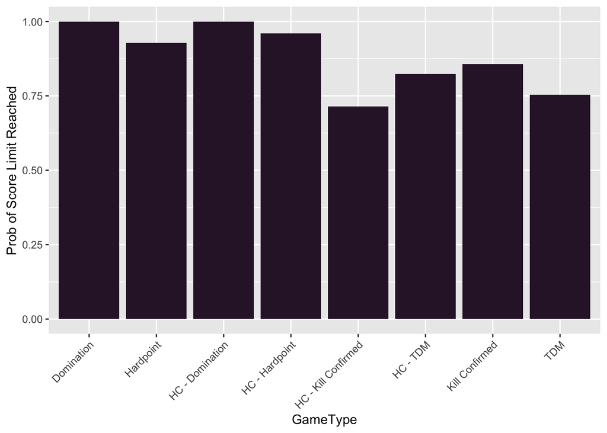

```r
ggplot(limitList, aes(x=GameType,y=limitProb)) +
  geom_bar(stat = "identity", fill = "#301934") +
  theme(axis.text.x=element_text(angle=45, hjust=1)) +
  ylab("Prob of Score Limit Reached")
```

We created a histogram to better visualize our results. The Game Types of Domination and Hardpoint in both Hard Core and normal mode have the highest chances of reaching the score limit, with domination reaching it 100% of the time. This may be because these game modes are more objective based with teams attaining extra points for capturing a zone or accomplishing an objective as opposed to surviving till the time limit.

### Task 2 (Inference):

#### Research Question: Which predictors are associated with the TotalXP?

```r
subCODGames <- CODGames %>% select(1:16) #remove cols where almost every row is NA
model <- lm(TotalXP ~ ., data = subCODGames) #build the linear model
step_result <- step(model, direction = "backward") # backward-elimination for vars with best p-value
```

```
## Start:  AIC=13116.55
## TotalXP ~ Map1 + Map2 + Choice + MapVote + Date + FullPartial +
##     Result + Eliminations + Deaths + Score + Damage + PrimaryWeapon +
##     XPType + DidPlayerVote + GameType
##
##                  Df  Sum of Sq        RSS   AIC
## - DidPlayerVote   1    1263291 1648678826 13115
## <none>                         1647415535 13117
## - Eliminations    1    6372645 1653788180 13118
## - FullPartial     1    9302872 1656718407 13119
## - Damage          1   11193034 1658608569 13120
## - Deaths          1   19724141 1667139676 13124
## - GameType        3   46762017 1694177551 13133
## - PrimaryWeapon  18  132062419 1779477953 13143
## - Choice         34  298335983 1945751517 13183
## - Map2           30  314289546 1961705081 13198
## - Map1           38  374587494 2022003029 13206
## - MapVote        23  335766151 1983181686 13220
## - Score           1  288261727 1935677262 13245
## - Date          114 1039454119 2686869653 13284
## - XPType          1  565437326 2212852860 13353
## - Result        382 4983229979 6630645514 13478
##
## Step:  AIC=13115.17
## TotalXP ~ Map1 + Map2 + Choice + MapVote + Date + FullPartial +
##     Result + Eliminations + Deaths + Score + Damage + PrimaryWeapon +
##     XPType + GameType
##
##                  Df  Sum of Sq        RSS   AIC
## <none>                         1648678826 13115
## - Eliminations    1    6667280 1655346106 13116
## - FullPartial     1    8947463 1657626289 13118
## - Damage          1   11238985 1659917811 13119
## - Deaths          1   19973951 1668652777 13123
## - GameType        3   46425491 1695104317 13132
## - PrimaryWeapon  18  132613241 1781292067 13142
## - Choice         34  313115946 1961794772 13188
## - Map2           30  319507275 1968186101 13198
## - Map1           38  379179780 2027858606 13206
## - MapVote        23  343644707 1992323533 13222
## - Score           1  291906354 1940585180 13245
## - Date          114 1059397029 2708075854 13288
## - XPType          1  573527667 2222206493 13354
## - Result        382 5060630395 6709309221 13485
```

#### Research Question: Of the predictors associated with the response, select one of the predictors and explain the relationship between the predictor and TotalXP.

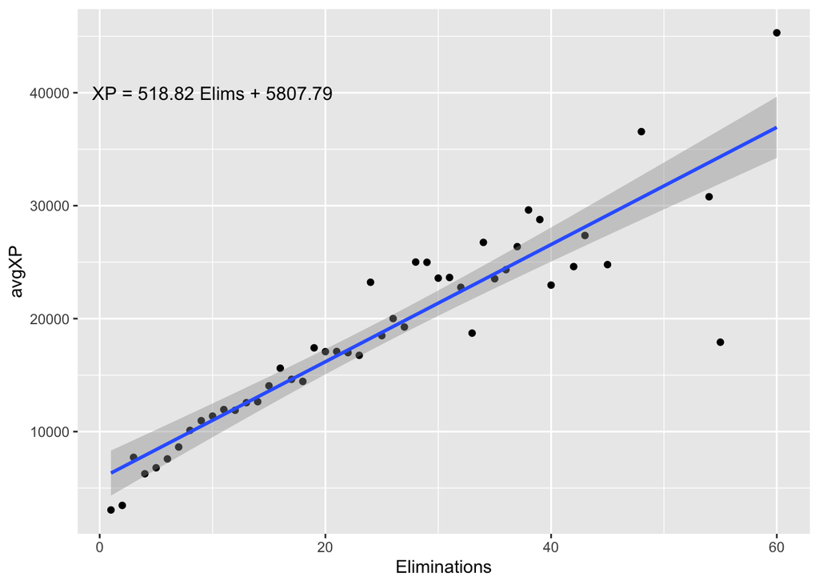

```r
groupElim <- CODGames %>% group_by(Eliminations) %>% summarize(avgXP = mean(TotalXP)) #group by num of eliminations and average the TotalXP
elim.reg <- lm(avgXP ~ Eliminations, data = groupElim) #create the lm to report the slope/intercept later
string <- paste("XP =",round(elim.reg$coefficients[[2]],2),"Elims +",round(elim.reg$coefficients[[1]],2)) #turn lm coeff into a formula string
ggplot(groupElim, aes(x=Eliminations, y=avgXP)) + geom_point() +  #ggplot with method lm and the formula string created above
  geom_smooth(method = "lm") + annotate("text",x = 10, y = 40000, label = string,size = 4)
```

### Task 3: Prediction

For this task, we wish to compare classification models on PrimaryWeapon, a variable that provides the primary weapon of the player used during a game. As such, we will formulate an appropriate research question:

- Up to what accuracy can we identify the primary weapon the player carries in a game?

We do not expect very high accuracies, mainly because of the large quantity of levels in PrimaryWeapon.

```r
levels(factor(subCODGames$PrimaryWeapon))
```

```
##  [1] ""              "AK-47"         "AUG"           "AUG "
##  [5] "DMR 14"        "FARA-83"       "FFAR 1"        "Groza"
##  [9] "Krig 6"        "KSP 45"        "LC-10"         "M16"
## [13] "M60"           "Magnum"        "MG 82"         "Milano"
## [17] "Milano 821"    "MP5"           "Pelington 703" "Pellington"
## [21] "QBZ-83"        "RPD"           "ShadowHunter"  "Type 63"
## [25] "XM4"
```

To answer our question, we first need to modify the dataset to…

- remove rows with NAs, since they interfere with model building.
- massage explanatory variables, since some are in formats that can’t be used in models (such as Result).
  - The example given (Result) is turned into a three-level categorical variable with values that are more easily interpreted/used in models (“Win”, “Loss”, and “Draw”).
  - Other variables (including the response) are cleaned of special characters and whitespace to assist the “dummy_cols” function, which helps create indicator variables.
- convert categorical variables to indicators, since kNN and SVM, models we plan on using, require scaled quantitative data.

```r
# Cleaning the data from NAs
subCODGames <- subCODGames %>% drop_na()

# Function to help separate Result into a categorical variable
matchResult <- function(x){
  results <- str_split(x, "-")[[1]]
  diff <- strtoi(results[1]) - strtoi(results[2])
  if(diff < 0){
    return("Loss")
  } else if (diff > 0) {
    return("Win")
  } else {
    return("Draw")
  }
}
# Separating Result into a categorical variable
subCODGames$ResultCat <- apply(data.frame(subCODGames$Result), 1, matchResult)

# Remove spaces and special characters from categorical variable values
cat_vars = c('Map1', 'Map2', 'Choice', 'FullPartial', 'ResultCat', 'XPType', 'DidPlayerVote', 'GameType')
for(cat_var in c(cat_vars, "PrimaryWeapon")){
  subCODGames[,cat_var] <- apply(data.frame(subCODGames[,cat_var]), 1, str_replace_all, pattern=" ", replacement="_")
  subCODGames[,cat_var] <- apply(data.frame(subCODGames[,cat_var]), 1, str_replace_all, pattern="-", replacement="_")
  subCODGames[,cat_var] <- apply(data.frame(subCODGames[,cat_var]), 1, str_replace_all, pattern="'", replacement="_")
  subCODGames[,cat_var] <- apply(data.frame(subCODGames[,cat_var]), 1, str_replace_all, pattern="%", replacement="percent")
  subCODGames[,cat_var] <- apply(data.frame(subCODGames[,cat_var]), 1, str_replace_all, pattern="\\+", replacement="plus")
}

# Substitute "AUG_" with "AUG" in PrimaryWeapon
subCODGames$PrimaryWeapon <- apply(data.frame(subCODGames$PrimaryWeapon), 1, str_replace_all, pattern="AUG_", replacement="AUG")

# Make PrimaryWeapon a factor (useful for model building)
subCODGames$PrimaryWeapon <- as.factor(subCODGames$PrimaryWeapon)

# Make dummy variables (indicators) for each categorical variable
subCODGames_dummy <- dummy_cols(subCODGames, select_columns = cat_vars, remove_selected_columns = TRUE)
```

For the models we create, we wish to use as many variables as possible, however, some of them are not suited for model building. Result has already been modified into ResultCat, so we plan on removing Result. We also remove Date, since dates are poor predictors for a variable like PrimaryWeapon. MapVote is in a format that does not suit models, and like Date, doesn’t appear to be a good predictor for weapon type.

```r
# Deselect variables that aren't useful
badVars <- c("Date", "Result", "MapVote")
subCODGames_dummy <- subCODGames_dummy %>% select(-badVars)
```

Now, we scale the predictors and perform an 80/20 split of the data into a Train and Test dataset. We use the random seed 123 to perform the random split, different seeds may result in different accuracies. Future studies may wish to use cross validation instead. The Train will be used to train the models, and the Test will be used to test and compare predictive accuracies of the models.

```r
# Select x variables for model building purposes
xvars <- names(select(subCODGames_dummy, -PrimaryWeapon))
# Scale the x variables (mainly for the kNN model)
subCODGames_dummy[,xvars] <- scale(subCODGames_dummy[,xvars], center = TRUE, scale = TRUE)

set.seed(123)
inds <- sample(1:nrow(subCODGames_dummy), floor(.8*nrow(subCODGames_dummy)))
Train <- subCODGames_dummy[inds, ]
Test <- subCODGames_dummy [-inds, ]
set.seed(NULL)
```

In the end, we have 3 new datasets. The first is the full massaged and scaled dataset, which has 808 observations and 139 variables.

```r
# Dimensions of the full massaged and scaled dataset
dim(subCODGames_dummy)
```

```
## [1] 808 139
```

```r
dim(Train)
```

```
## [1] 646 139
```

Finally, we created the Test dataset which has the leftover 20% of the full data (162 observations).

```r
dim(Test)
```

```
## [1] 162 139
```

#### Random Forest

The first model we create is a random forest. Random forest is a type of ensemble method, where many weak learners (in this case, decision trees) are fitted to bootstrapped samples of the dataset on a subset of variables. Data that is not used for fitting each learner is called “out-of-bag” data, and is used by each learner to form predictions. These predictions by each learner are then combined using a method called bootstrap aggregating (bagging) to create a much stronger predictive model.

We use the randomForest function to fit the model, and we set the number of trees (ntrees) to be the default (500). We also keep the number of variables to consider at each split (mtry) at the default value, which is $\sqrt{\text{139}}$.

```r
set.seed(123)
model_rf <- randomForest(PrimaryWeapon ~ ., data = Train, ntrees = 500)
set.seed(NULL)

predictsRf <- predict(model_rf, newdata = Test, type="response")

cat("Accuracy Random Forest:", mean(predictsRf == Test$PrimaryWeapon))
```

```
## Accuracy Random Forest: 0.2222222
```

We get an accuracy score of 0.22, a low number as expected from the sheer number of levels PrimaryWeapon holds.

#### kNN Classification

The second model we create, k-Nearest Neighbors (kNN), is a simple classification model that, given a data point (scaled predictors) takes the class of the majority of its k-neighbors. Neighbors are decided using distance functions like Euclidean. The need for distance functions is the main reason why we scale the data (as low magnitude values like indicators would get overruled by larger magnitude quantitative values).

To find the appropriate k value, we iterate from 2 to 50 (an arbitrarily high value). For each kNN model, we calculate its accuracy on the test and store it in a vector. In the end, we display these accuracies in a graph and pick the k value that produces the highest accuracy.

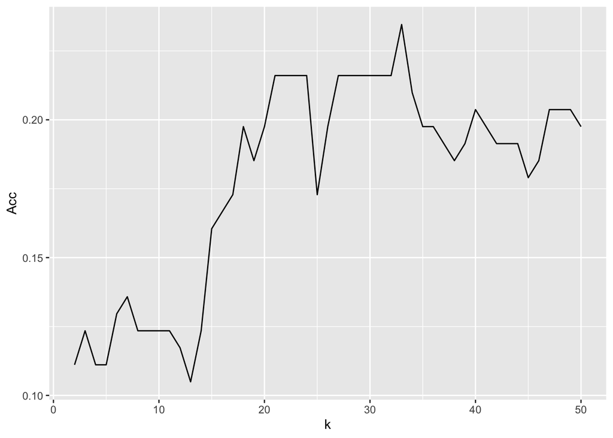

```r
accvec <- rep(NA,50)

for (x in 2:50) {
  knn_res <- knn(train = Train[,xvars,drop=FALSE],
               test = Test[,xvars,drop=FALSE],
               cl=Train$PrimaryWeapon,
               k=x)

  accvec[x] <-  mean(Test$PrimaryWeapon == as.character(knn_res))
}

# Store results as a dataframe
k_compare <-  data.frame(k = 2:50, Acc=accvec[-1])

# Display a graph of the results to visualize the best k
ggplot(data=k_compare, aes(x=k,y=Acc)) +
  geom_line()
```

```r
cat("Accuracy KNN:",k_compare$Acc[33-1])
```

```
## Accuracy KNN: 0.2345679
```

The highest accuracy displayed in the graph is 0.235, which comes from the k=33 neares neighbors model. This accuracy is higher than what we observed from the random forest classifier, though still low in general.

#### SVMs

Our final model are Support Vector Machines (SVMs) which aim to find hyperplanes that can classify the observations (data points). It accomplishes this while also maximizing the distance between the hyperplane and the data points on either side of the divide. The figure below better illustrates how the hyperplane divides observations.

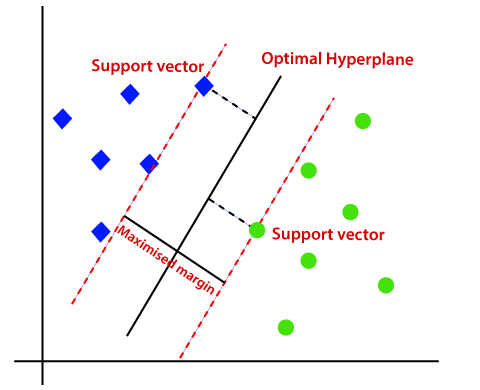

Explanation of SVM

The ksvm() function comes from the package “[kernLabs](https://cran.r-project.org/web/packages/kernlab/index.html)”, which is mainly used to implement kernel-based machine learning methods. The inputs for ksvm() are the same as for the base linear regression function lm(), a formula and a specification for the dataset. There are many other inputs that the function provides, such as type or kernel, but for this analysis we leave them to their defaults. As our response is a multi-level categorical variable, the resulting SVM model uses a “one-against-one” approach, where k(k-1)/2 binary classifiers (k = number of classes) are trained on the provided data and predictions are chosen through a voting scheme, like an ensemble model.

```r
modelSVM <- ksvm(PrimaryWeapon ~ ., data = Train)

predictions <- predict(modelSVM, newdata = Test)

contingency_table <- table(predictions, Test$PrimaryWeapon)

accuracy <- sum(diag(contingency_table)) / sum(contingency_table)

cat("Accuracy SVM:",accuracy)
```

```
## Accuracy SVM: 0.2283951
```

The SVM model has an accuracy of 0.228, which is better than our random forest model, but worse than our best kNN model.

#### Conclusion

# Report Conclusion

In this report we analyzed Call of Duty game data and and built models to answer given and self-derived research questions. We began by loading, cleaning, and manipulating the given csv files so that they can be easier to work with. For our first task we wanted to understand which game mode will first attain the desired score limit. We utilized various data manipulation techniques to conclude that Domination and Hardpoint (Hardcore and Normal) would be the first to reach the score limit. For the second task we were asked to identify which variables (predictors) were associated with TotalXP. For this task we end up concluding that Eliminations was a key predictor and showcased a strong positive linear relationship with TotalXP. Finally, in task 3, we compared classification models to identify up to what accuracy we could predict which primary weapon the player carries in a game. We utilized Random Forest, SVM and KNN to answer this question. Our results told us that KNN classification gave us the highest accuracy of 0.235.

Ultimately our analysis throughout the report made us realize how important it is to have clean and organized data to work with in order to achieve good results. This dataset was especially unorganized and full of typos which made it harder to deal with and required a lot more preparation. Our biggest takeaway was that we spent the most time organizing the data to be used in the models in order to achieve outputs from our created models.